# STAT 361 - RECITATION 10

### 2. Scott’s Normal Reference Rule:

To select an optimal (or good) smoothing parameter for density estimation, one needs to establish a criterion for comparing smoothing parameters. One approach aims to minimize the squared error in the estimate. Following Scott’s approach, we briefly summarize some of the main ideas on $L_2$ criteria.

**Scott's normal reference rule is optimal for random samples of normally distributed data, in the sense that it minimizes the integrated mean squared error of the density estimate**

MSE of a density estimator $\hat{f}(x)$ at x is

$$ \textrm{MSE}(\hat{f}(x)) =E(\hat{f}(x) - f(x))^2 = V(\hat{f}(x)) + \textrm{bias}^2(\hat{f}(x)) $$

It is simpler to consider the statistic, mean integrated squared error (MISE), given by

$$ \textrm{MISE} = \int E(\hat{f}(x) - f(x))^2 dx = \int \textrm{MSE}(\hat{f}(x)) $$

with Asymptotic MISE;

$$ \textrm{AMISE}^* = [\frac{9}{16} \int f'(x)^2dx ]^{1/3} n^{-2/3} $$

In density estimation f is unknown, so the optimal h cannot be computed exactly, but the asymptotically optimal h depends on the unknown density only through its first derivative.

where $\sigma^2$ is an estimate of the population standard deviation.

### Lets look at what should be the optimal bin width for Sepal.Widht in "iris" dataset;

**a)** using Scott’s Normal Reference Rule

**b)** using Sturges’ Rule, and compare them

```r
head(iris)
```

| Sepal.Length | Sepal.Width | Petal.Length | Petal.Width | Species |
| --- | --- | --- | --- | --- |
| 5.1 | 3.5 | 1.4 | 0.2 | setosa |
| 4.9 | 3.0 | 1.4 | 0.2 | setosa |
| 4.7 | 3.2 | 1.3 | 0.2 | setosa |
| 4.6 | 3.1 | 1.5 | 0.2 | setosa |
| 5.0 | 3.6 | 1.4 | 0.2 | setosa |
| 5.4 | 3.9 | 1.7 | 0.4 | setosa |

## Let firts write the function of Scotts rule;

```r
scotts <- function(x){
    n <- length(x) #sample size
    h <- 3.5 * sd(x) * n^(-1/3) #bin width according to scotts rule
    nclass <- ceiling(diff(range(x)) / h) #number of classes for histogram

    breaks <- min(x) + h * 0:nclass #breaks for histogram

    return(list(nclass = nclass, h = h, breaks = breaks))
}
```

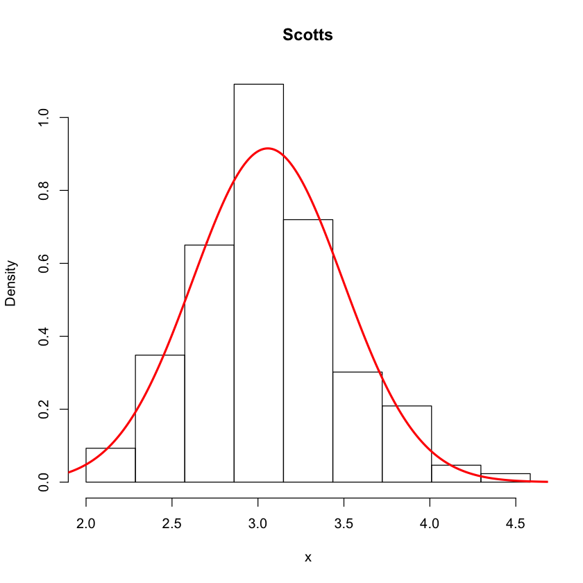

```r
x <- iris$Sepal.Width


h.scott <- hist(x, breaks = scotts(x)$breaks, freq = FALSE, main = "Scotts")

z_scott <- seq(min(x) - scotts(x)$h, max(y) + scotts(x)$h, 0.01)
lines(z_scott, dnorm(z_scott,mean = mean(iris$Sepal.Width), sd = sd(iris$Sepal.Width)), col = "Red", lwd = 2.5)
```

```r
# breaks
round(h.scott$breaks, 1)
```

1. 2

2. 2.3

3. 2.6

4. 2.9

5. 3.1

6. 3.4

7. 3.7

8. 4

9. 4.3

10. 4.6

```r
# counts; number of obsv in each bar

h.scott$counts
```

1. 4

2. 15

3. 28

4. 47

5. 31

6. 13

7. 9

8. 2

9. 1

```r
scotts(x)$h #The bin width according to Scotts’ rule
```

0.28711611452997

### Then, suppose $x_0 = 3.6$. Let find which bin does $x_0$ correspond to and what is the density of $x_0 = 3.6$ according to Scotts' Rule.

```r
x0 <- 3.6

b <- which.min(h.scott$breaks <= x0) - 1
print(c(b, h.scott$density[b]))
```

```
[1] 6.0000000 0.3018523
```

- In the scotts histogram $\hat {f_1}$, the point $x_0$ = 3.6 is in bin 6, and $\hat {f_1}(3.6)$ = 0.302.

Alternately, the density estimate is the relative frequency weighted by bin width.

```r
n= nrow(iris)

h.scott$counts[6] / (n * scotts(x)$h)
```

0.301852324828741

### Then, let show the histogram of sepal.width with Sturges rule;

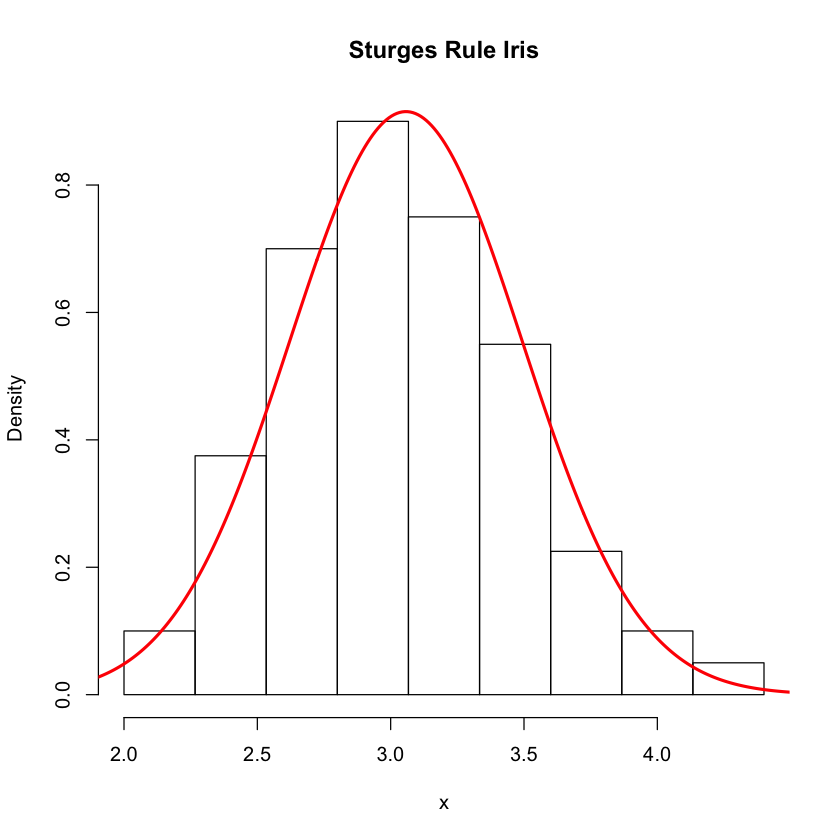

```r
set.seed(1234)

x <- iris$Sepal.Width
z_sturges <- seq(min(x) - sturges(x)$cwidth, max(x) + sturges(x)$cwidth, 0.01) #create for adding line

h.sturges_iris <- hist(x, breaks = sturges(x)$breaks, prob = TRUE, main = "Sturges Rule Iris")
lines(z_sturges, dnorm(z_sturges, mean = mean(iris$Sepal.Width), sd=sd(iris$Sepal.Width)),col = "red", lwd = 2.5)
```

```r
x0 <- 3.6

b <- which.min(h.sturges_iris$breaks <= x0) - 1
print(c(b, h.sturges_iris$density[b]))
```

```
[1] 6.00 0.55
```

- In the sturges histogram $\hat {f_1}$, the point $x_0$ = 3.6 is in bin 6, and $\hat {f_1}(3.6)$ = 0.55.

Alternately, the density estimate is the relative frequency weighted by bin width.

```r
h.sturges_iris$counts[6] / (nrow(iris) * sturges(x)$cwidth)
```

0.55

### 3. Freedman-Diaconis Rule:

Scott’s normal reference rule above is a member of a class of rules that select the optimal bin width according to a formula $\hat{h} = T_n^{−1/3}$, where T is a statistic. These $n^{−1/3}$ rules are related to the fact that the optimal rate of decay of bin width with respect to $L_p$ norms is $n^{−1/3}$. The Freedman-Diaconis Rule is another member of this class. For the FD rule, the statistic T is twice the sample interquartile range. That is,

$$ \hat{h} = 2 * (\textrm{IQR}) * n^{−1/3}, \textrm{IQR = interquartile range} $$

The IQR is less sensitive than sample standard deviation to outliers in the data.

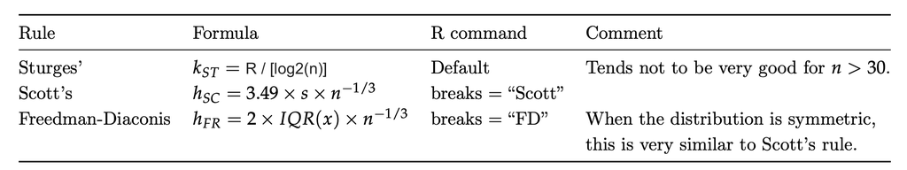

### Lets look at what should be the optimal bin width for Sepal.Widht in "iris" dataset with Freedman-Diaconis Rule;

## Firstly, let write function of Freedman-Diaconis Rule:

```r
FD <- function(x){

    n <- length(x) #sample size

    h <- 2 * IQR(x) * n^(-1/3) # bin width

    nclass <- ceiling(diff(range(x)) / h) # number of classes in histogram

    breaks <- min(x) + h * 0:nclass #breaks of histogram

    return(list(nclass = nclass, h = h, breaks = breaks))
}
```

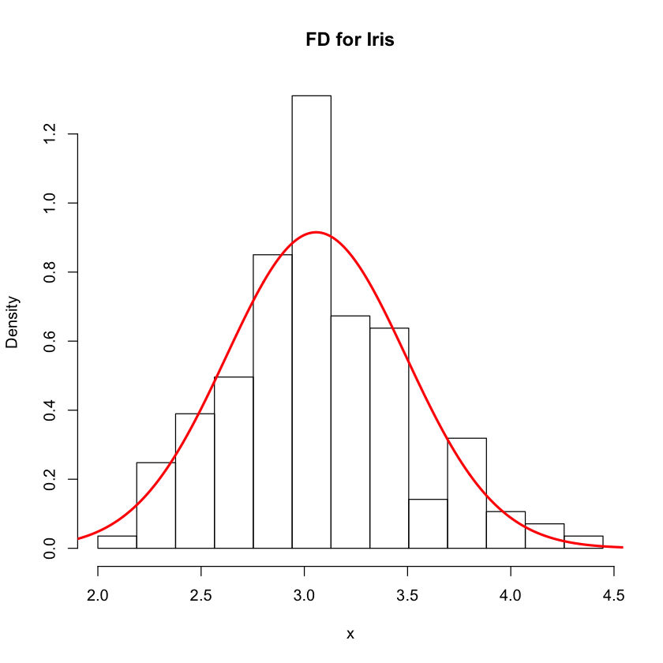

```r
x <- iris$Sepal.Width

h.FD <- hist(x, breaks = FD(x)$breaks, freq = FALSE, main = "FD for Iris")

z_fd <- seq(min(x) - FD(x)$h, max(y) + FD(x)$h, 0.01)

lines(z_fd, dnorm(z_fd,mean = mean(iris$Sepal.Width), sd = sd(iris$Sepal.Width)), col = "Red", lwd = 2.5)
```

### Then, suppose $x_0 = 3.6$. Let find which bin does $x_0$ correspond to and what is the density of $x_0 = 3.6$ according to FD Rule.

```r
x0 <- 3.6
b <- which.min(h.FD$breaks <= x0) - 1
print(c(b, h.FD$density[b]))
```

```
[1] 9.0000000 0.1416878
```

- In the FD histogram $\hat {f_1}$, the point $x_0$ = 3.6 is in bin 9, and $\hat {f_1}(3.6)$ = 0.14.

Alternately, the density estimate is the relative frequency weighted by bin width.

```r
h.FD$counts[9] / (nrow(iris) * FD(x)$h)
```

0.141687809224348

## Frequency Polygon Density Estimate:

All histogram density estimates are piecewise continuous but not continuous over the entire range of the data. A frequency polygon provides a continuous density estimate from the same frequency distribution used to produce the histogram. The frequency polygon is constructed by computing the density estimate at the midpoint of each class interval, and using linear interpolation for the estimates between consecutive midpoints.

For normal densities, the optimal frequency polygon bin width is $$ h_n^{fp} = 2.15 * \sigma * n^{-1/5} $$

### Lets look at what should be the optimal histogram for Sepal.Widht in "iris" dataset with Frequency Polygon Density Estimate;

## Firstly, let write function of Frequency Polygon Density Estimate:

```r
freq_poly <- function(x){

    n <- length(x) #sample size

    h <- 2.15 * sd(x) * n^(-1/5) # bin width

    #pretty; Compute a sequence of about n+1 equally spaced ‘round’ values which cover the range of the values in x.
    #The values are chosen so that they are 1, 2 or 5 times a power of 10.

    br <- pretty(x, diff(range(x)) / h) # number of classes in histogram

    brplus <- c(min(br)-h, max(br+h)) #breaks

    return(list(brplus = brplus, h = h, br = br))
}
```

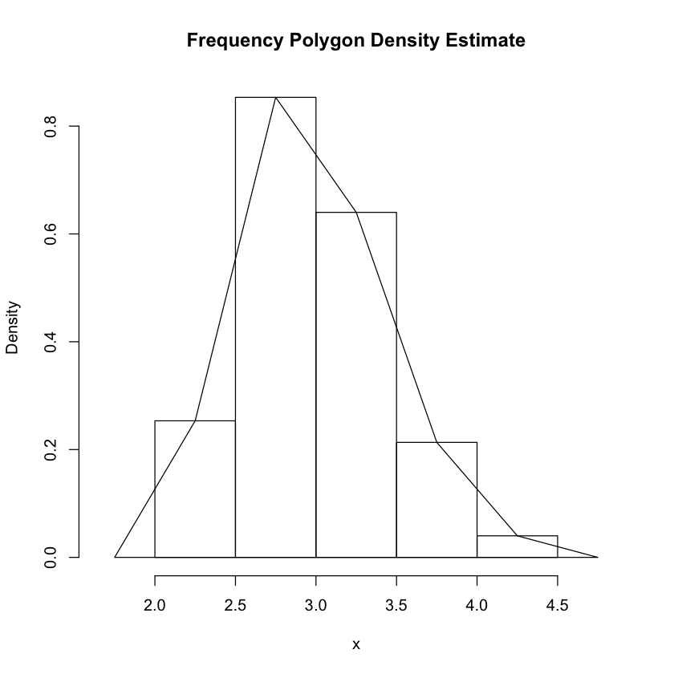

```r
x <- iris$Sepal.Width

h.freq <- hist(x, breaks = freq_poly(x)$br, freq = FALSE, main = "Frequency Polygon Density Estimate",
               xlim = freq_poly(x)$brplus)

#density est at vertices of polygon
vx <- h.freq$mids
vy <- h.freq$density
delta <- diff(vx)[1] # h after pretty is applied

k <- length(vx)
vx <- vx + delta # the bins on the ends

vx <- c(vx[1] - 2 * delta, vx[1] - delta, vx)
vy <- c(0, vy, 0)
# add the polygon to the histogram
polygon(vx, vy)
```

## The Averaged Shifted Histogram:

The optimal bin width does not determine the location of the center or endpoints of the bin, however. For example, using truehist (MASS), we can easily shift the bins from left to right using the argument $x_0$, while keeping the bin width constant. Shifting the class boundaries changes the density estimates, so several different density estimates are possible using the same bin width.

The Average Shifted Histogram (ASH) proposed by Scott averages the density estimates. That is, the ASH estimate of density is

$$ \widehat{f_{ash}}(x) = \frac{1}{m}\sum_{j = 1}^{m} \hat{f_j}(x) $$

where the class boundaries for estimate $\hat{f}_{j+1}(x)$ are shifted by $h/m$ from the boundaries for $\hat{f}_{j}(x)$. Here we are viewing the estimates as m histograms with class width h. Alternately we can view the ASH estimate as a histogram with widths $h/m$. The optimal bin width for the naive ASH estimate of a Normal($\mu, \sigma^2$) density is

$$ h = 2.576 * \sigma * n^{-1/5} $$

- An Average Shifted Histogram (ASH) constructs a density estimate by averaging together estimates produced by a set of shifted histograms.

Also remember, the histogram density estimate based on a sample size n is:

$$ \hat{f(x)}=\frac{vk}{nh}, t_k \le x \le t_{k+1} $$

where where νk is the number of sample points in the class interval [tk, tk+1).

## Lets look at what should be the optimal histogram for Sepal.Widht in "iris" dataset with Averaged Shifted Histogram with m=2;

```r
x <- iris$Sepal.Width

n <- length(x)

h <- 2.576 * sd(x) * n^(-1/5) #bin with formula

a <- min(x) - 0.5
b <- max(x) + 0.5

m <- 2


delta <- h / m #boundaries for estimate  f.hat(x+1) are shifted by  h/m



breaks <- seq(a - h, b + 2*h, delta) #breaks formula for ASH

hist.ash <- hist(x, breaks = breaks, plot = FALSE)
```

```r
nk <- hist.ash$counts

K <- abs((1-m):(m-1))

fhat <- function(x){
    i <- max(which(x > breaks))
    k <- (i - m + 1):(i + m - 1)
    vk <- nk[k]
    sum((1 - K / m) * vk) / (n * h)
}
fhat(3.6)
```

0.32348776017942

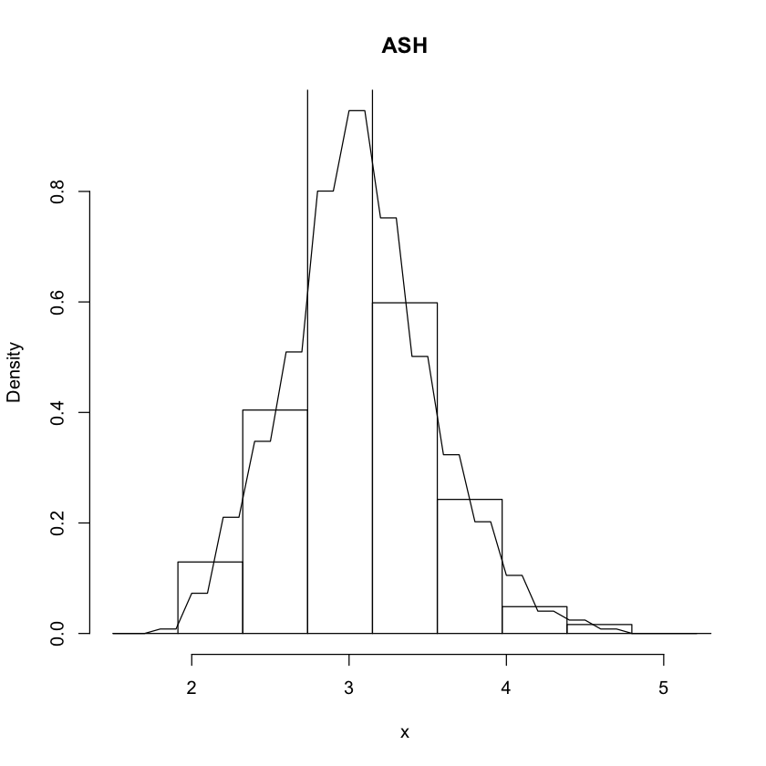

```r
# density can be computed at any points in range of data
z_ash <- as.matrix(seq(a, b + h, 0.1))

f.ash <- apply(z_ash, 1, fhat) #density estimates at midpts


# plot ASH density estimate over histogram
breaks2 <- seq(a, b + h, h)
hist(x, breaks = breaks2, freq = FALSE, main = "ASH", ylim = c(0, max(f.ash)))
lines(z_ash, f.ash, xlab = "x")
```

## Kernel Density Estimation:

Kernel density estimation is a non-parametric method of estimating the probability density function (PDF) of a continuous random variable. It is non-parametric because it does not assume any underlying distribution for the variable. Kernel density estimation is a fundamental data smoothing problem where inferences about the population are made, based on a finite data sample.

Let $(x_1, x_2, …, x_n)$ be a univariate independent and identically distributed sample drawn from some distribution with an unknown density $f$. We are interested in estimating the shape of this function $f$. Its kernel density estimator is

$$ \hat{f}_K(x) = \frac{1}{n} \sum_{i=1}^n \frac{1}{h} K (\frac{x-X_i}{h}) $$

where K is the kernel — a non-negative function — and h > 0 is a smoothing parameter called the bandwidth.

### Bandwidth selection:

If Gaussian basis functions are used to approximate univariate data, and the underlying density being estimated is Gaussian, the optimal choice for h (that is, the bandwidth that minimises the mean integrated squared error) is:

$$ h = 1.06 * \hat{\sigma} * n^{-1/5} $$

This choice of bandwidth is an optimal (IMSE) choice when the distribution is normal. If the true density is not unimodal, however, will tend to oversmooth. Alternately, one can use a more robust estimate of dispersion in, setting

$$ \hat{\sigma} = min(S, IQR/1.34) $$

where S is the standard deviation of the sample. Silverman indicates that an even better choice for a Gaussian kernel is the reduced width

$$ h = 0.9 * min(S, IQR/1.34) * n^{-1/5} $$

which is a good starting point appropriate for a wide range of distributions that are not necessarily normal, unimodal, or symmetric.

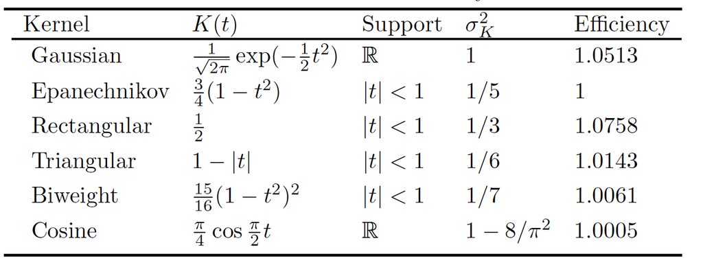

## Using Kernel Density Estimation method (use gaussian kernel), let draw density plot of Sepal.Width

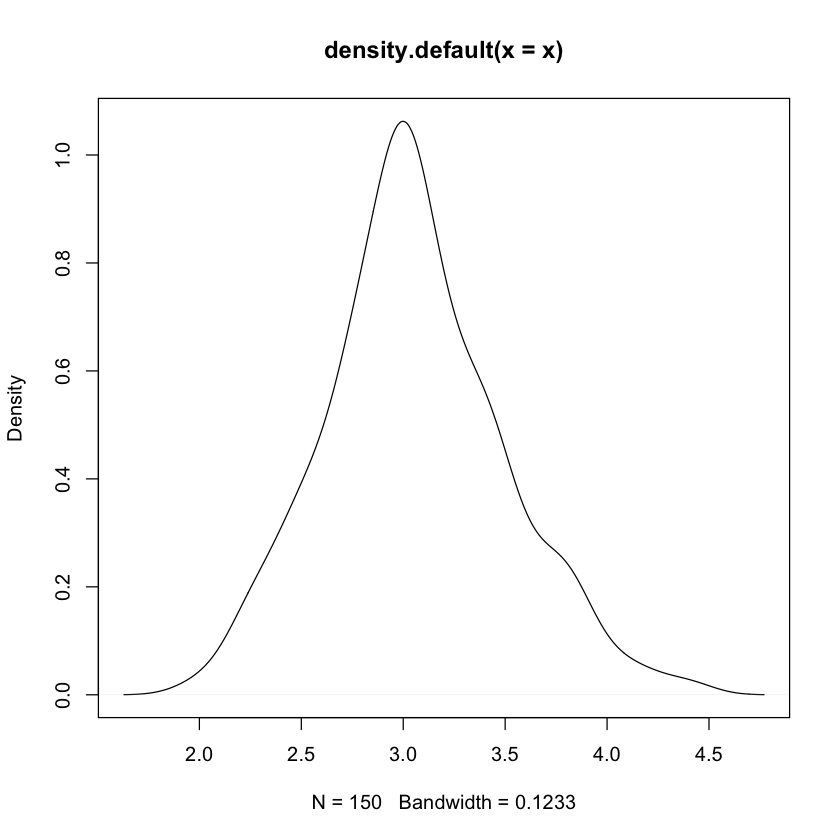

```r
x <- iris$Sepal.Width

n <- length(x)
h <- 0.9 * min(sd(x), IQR(x)) * n ^ (-1/5)
plot(density(x))
```

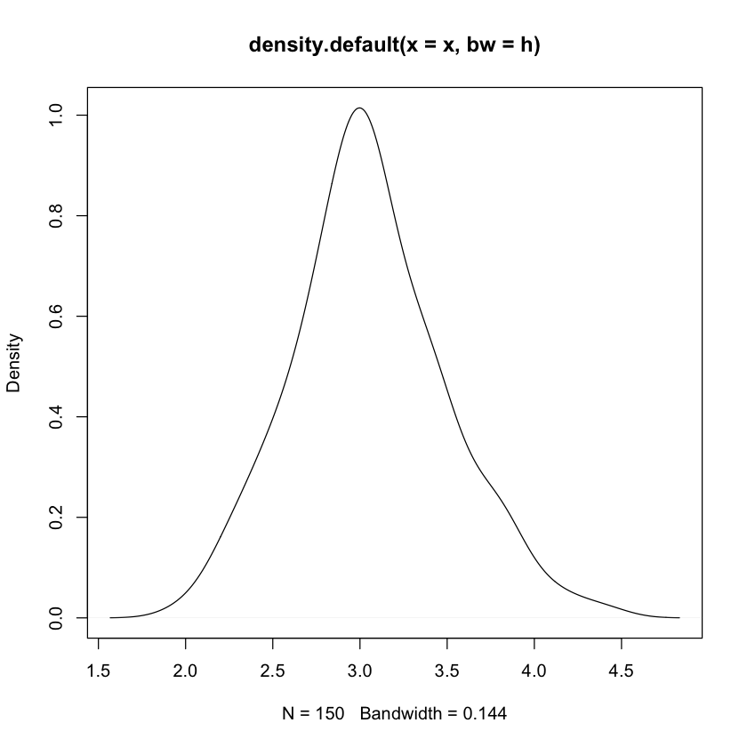

```r
plot(density(x, bw = h))
```

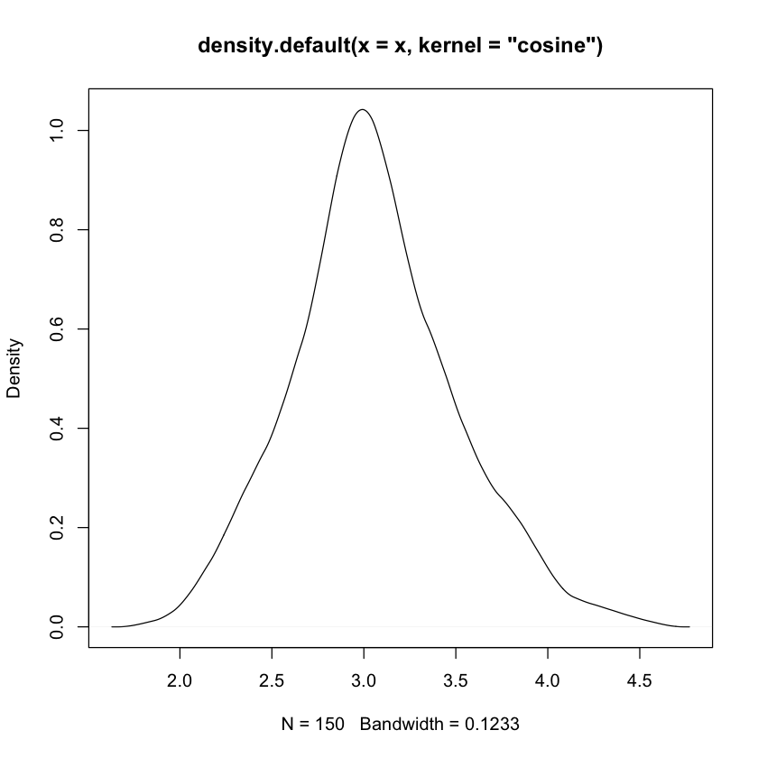

```r
plot(density(x, kernel = "cosine"))
```

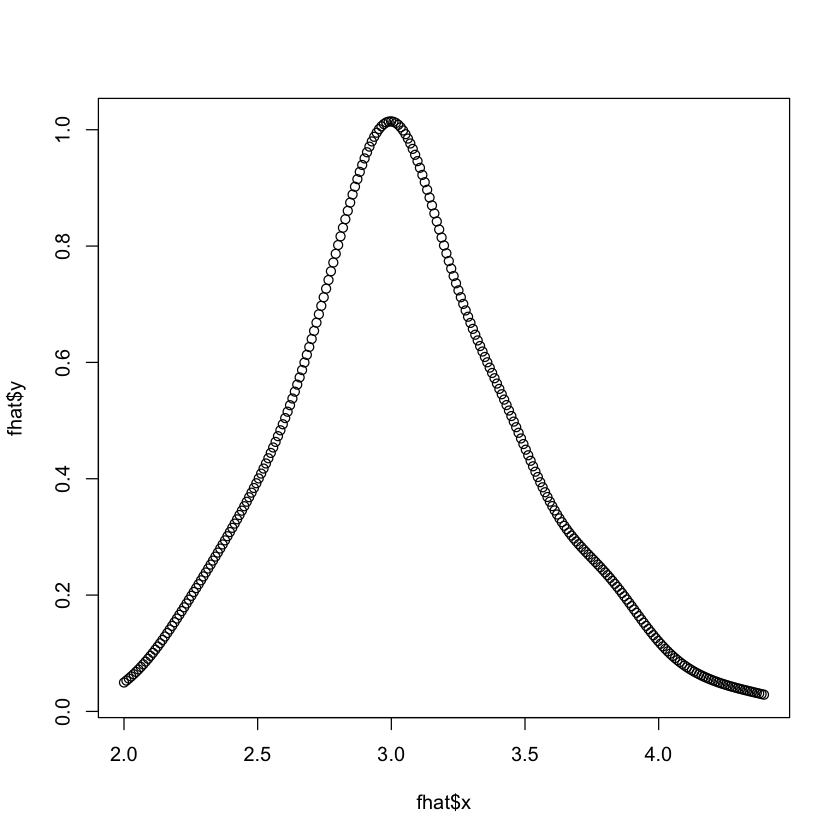

```r
d <- density(x, bw = h)
xnew <- seq(min(x), max(x), 0.009)
fhat <- approx(d$x, d$y, xout = xnew)
plot(fhat)
```

```r
approx(d$x, d$y, xout = c(3.6,3.9))
```

**$x**

1. 3.6

2. 3.9

**$y**

1. 0.354638588592258

2. 0.180340751608294

```r
n <- length(x) # sample size

h <- 0.9 * min(sd(x), IQR(x)) * n ^ (-1/5) #gaussian width

ND <- function(x){
    sqrt(2*pi)^(-1) * exp(-0.5 * x^2)}

K <- function(x,data){
    size <- length(x)
    out <- numeric(size)

    for(i in 1:size){
        out[i] <- mean(ND((x[i]-data)/h)/h)}

    return(out)
}
K(c(3.6,3.9),x)
```

1. 0.354159522987927

2. 0.18016645847954

## Boundary kernels:

Near the boundaries of the support set of a density, or discontinuity points, kernel density estimates have larger errors. Kernel density estimates tend to smooth the probability mass over the discontinuity points or boundary points.

### For "Sepal.Width", draw density plot and then take 2.5 as boundary and find a new density by using Boundary kernels.

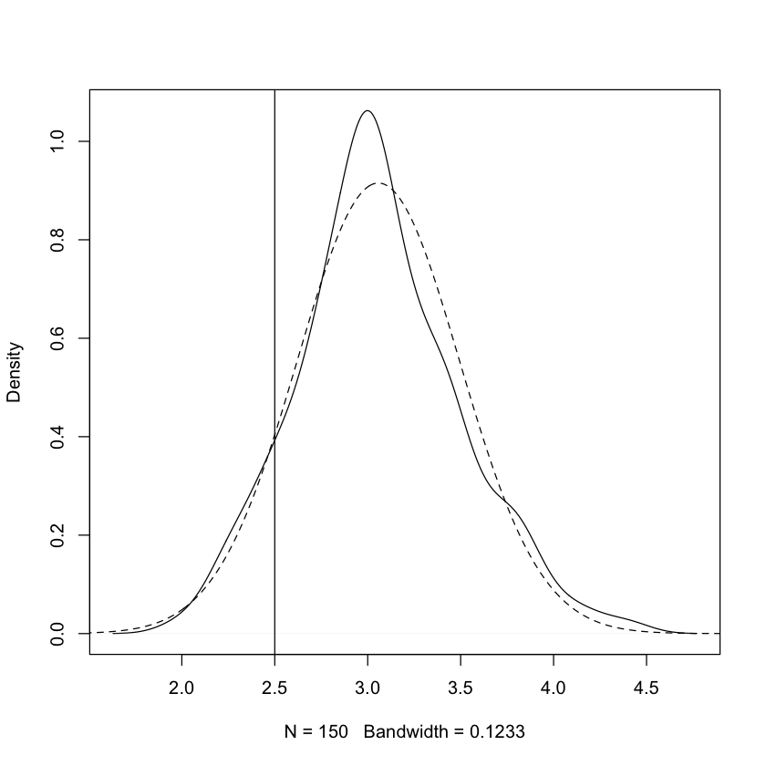

```r
x <- iris$Sepal.Width

n <- length(x)
plot(density(x), main="")

abline(v = 2.5)
y <- seq(-5,5, 0.01)

lines(y, dnorm(y, mean(iris$Sepal.Width), sd(iris$Sepal.Width)), lty = 2)
```

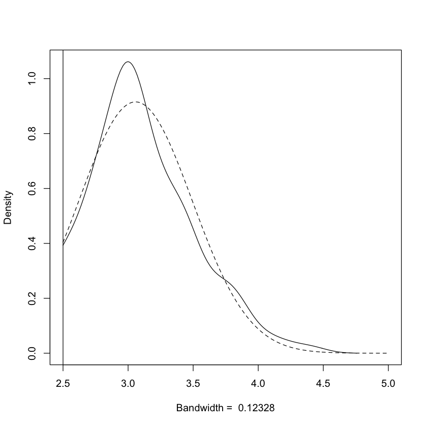

```r
#Reflection boundary technique
xx <- c(x, -x)
g <- density(xx, bw = bw.nrd0(x))
a <- seq(2.5, 5, .01)


ghat <- approx(g$x, g$y, xout = a)
fhat <- 2 * ghat$y # density estimate along a


bw <- paste("Bandwidth = ", round(g$bw, 5))


plot(a, fhat, type="l",xlim = c(2.5,5), main = "", xlab = bw, ylab = "Density")
abline(v = 2.5)


# add the true density to compare
y <- seq(2.5,5, .01)
lines(y, dnorm(y, mean(iris$Sepal.Width), sd(iris$Sepal.Width)), lty = 2)
```